# Homework Blk 2

```python
from sympy import *
from sympy.abc import x,y,z,u,v,w,t
from dtumathtools import *
init_printing()
```

$$1$$

$A$ : $5$

$B$ : $1$

$C$ : $3$

$D$ : $2$

$$2$$

$2.1$

```
Maximum Absolute Error: 3.630479331051539e-08
```

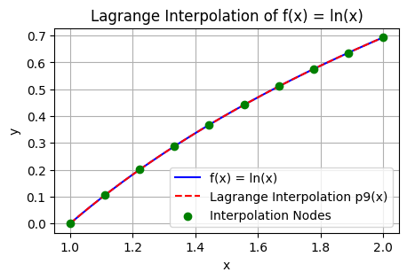

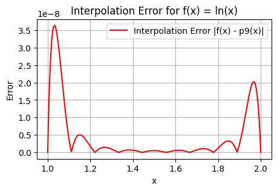

```python
import numpy as np
import matplotlib.pyplot as plt

def LagrangeFormInterpolation(knots, values, x):
    """
    Compute the Lagrange form interpolation at points x given the knots and values.
    """
    n = len(knots)
    P = np.zeros_like(x, dtype=float)
    for i in range(n):
        L = np.ones_like(x)
        for j in range(n):
            if j != i:
                L *= (x - knots[j]) / (knots[i] - knots[j])
        P += values[i] * L
    return P

# Define the function
def f(x):
    return np.log(x)

# Define the interval and the degree of the polynomial
a, b = 1, 2
n = 9

# Generate 10 equally spaced nodes in the interval [1, 2]
x_nodes = np.linspace(a, b, n + 1)
y_nodes = f(x_nodes)

# Generate 400 equally spaced points in the interval [1, 2] for evaluation
x_eval = np.linspace(a, b, 400)
f_eval = f(x_eval)

# Compute the Lagrange interpolation polynomial at the evaluation points
p9_eval = LagrangeFormInterpolation(x_nodes, y_nodes, x_eval)

# Compute the maximum absolute error
max_error = np.max(np.abs(f_eval - p9_eval))

print("Maximum Absolute Error:", max_error)

# Plot the original function and the interpolation polynomial
plt.figure(figsize=(5, 3))
plt.plot(x_eval, f_eval, label='f(x) = ln(x)', color='blue')
plt.plot(x_eval, p9_eval, label='Lagrange Interpolation p9(x)', linestyle='--', color='red')
plt.scatter(x_nodes, y_nodes, color='green', zorder=5, label='Interpolation Nodes')
plt.legend()
plt.xlabel('x')
plt.ylabel('y')
plt.title('Lagrange Interpolation of f(x) = ln(x)')
plt.grid(True)
plt.show()

# Plot the interpolation error
interpolation_error = np.abs(f_eval - p9_eval)
plt.figure(figsize=(5, 3))
plt.plot(x_eval, interpolation_error, label='Interpolation Error |f(x) - p9(x)|', color='red')
plt.legend()
plt.xlabel('x')
plt.ylabel('Error')
plt.title('Interpolation Error for f(x) = ln(x)')
plt.grid(True)
plt.show()
```

**In this code the graph of $f(x)= ln(x)$ is lagrange interpolated with $10$ equally spaced interval $[1,2]$, with the interpolation error $|f(x) - p_9(x)|$ being relatively small** at $: 3.630479331051539e-08$

$2.2$

```
Maximum Absolute Error: 8.858035061010128e-08
```

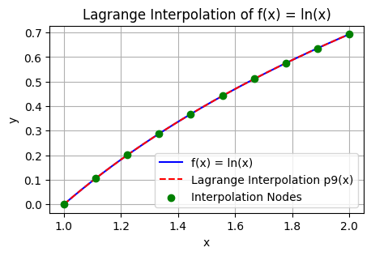

```
Theoretical Upper Bound of the Interpolation Error for P9: 2.60182419004690e-6
```

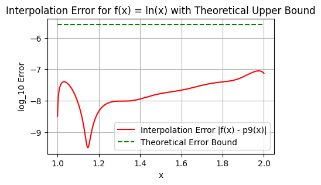

$\displaystyle 2.6018241900469 \cdot 10^{-6}$

```python
import numpy as np
import matplotlib.pyplot as plt
from scipy.interpolate import lagrange

# Define the function f(x) = ln(x)
def f(x):
    return np.log(x)

# Define the interval and the degree of the polynomial
a, b = 1, 2
n = 9

# Generate 10 equally spaced nodes in the interval [1, 2]
x_nodes = np.linspace(a, b, n + 1)
y_nodes = f(x_nodes)

# Generate 400 equally spaced points in the interval [1, 2]
x_eval = np.linspace(a, b, 400)
f_eval = f(x_eval)

# Compute the Lagrange interpolation polynomial at the evaluation points
p9 = lagrange(x_nodes, y_nodes)
p9_eval = p9(x_eval)

# Compute the maximum absolute error
max_error = np.max(np.abs(f_eval - p9_eval))

print("Maximum Absolute Error:", max_error)

# Plot the original function and the interpolation polynomial
plt.figure(figsize=(5, 3))
plt.plot(x_eval, f_eval, label='f(x) = ln(x)', color='blue')
plt.plot(x_eval, p9_eval, label='Lagrange Interpolation p9(x)', linestyle='--', color='red')
plt.scatter(x_nodes, y_nodes, color='green', zorder=5, label='Interpolation Nodes')
plt.legend()
plt.xlabel('x')
plt.ylabel('y')
plt.title('Lagrange Interpolation of f(x) = ln(x)')
plt.grid(True)
plt.show()

# Part 2.2: Theoretical Upper Bound of the Interpolation Error

# Calculate h
h = (b - a) / n

# Calculate the upper bound M of the 10th derivative of ln(x) on the interval [1, 2]
# Given |f^(n)(x)| = (n-1)! / x^n
factorial_9 = factorial(9)
M_a = factorial_9 / a**10
M_b = factorial_9 / b**10
M = max(M_a, M_b)

# Calculate the theoretical upper bound of the interpolation error using the second interpolation error theorem
error_bound = (1 / (4 * (n + 1))) * M * h**(n + 1)

print("Theoretical Upper Bound of the Interpolation Error for P9:", error_bound)

# Plot the interpolation error and the theoretical upper bound
interpolation_error = np.abs(f_eval - p9_eval)
theoretical_error_bound = np.full_like(x_eval, error_bound)

plt.figure(figsize=(5, 3))
plt.plot(x_eval, np.log10(interpolation_error), label='Interpolation Error |f(x) - p9(x)|', color='red')
plt.plot(x_eval, np.log10(theoretical_error_bound), label='Theoretical Error Bound', linestyle='--', color='green')
plt.legend()
plt.xlabel('x')
plt.ylabel('log_10 Error')
plt.title('Interpolation Error for f(x) = ln(x) with Theoretical Upper Bound')
plt.grid(True)
plt.show()
error_bound
```

```python
import numpy as np

# Define the interval and the degree of the polynomial
a, b = 1, 2
n = 9

# Calculate h
h = (b - a) / n

# Calculate the upper bound M of the 10th derivative of ln(x) on the interval [1, 2]
factorial_9 = math.factorial(9)
M_a = factorial_9 / a**10
M_b = factorial_9 / b**10
M = max(M_a, M_b)

# Calculate the theoretical upper bound of the interpolation error using the second interpolation error theorem
error_bound = (1 / (4 * (n + 1))) * M * h**(n + 1)

print("Theoretical upper bound of the interpolation error for P9:", error_bound)
```

```
Theoretical upper bound of the interpolation error for P9: 2.6018241900469016e-06
```

The second interpolation error theorem states that the error $ E_n(x) $ of the function $f(x)$ with the interpolation polynomial $ P_n(x) $ is given by: $$ \left| f(x) - P_n(x) \right| \leq \frac{1}{4(n+1)} \left| f^{n+1}(\xi) \right| h^{n+1} \leq \frac{1}{4(n+1)} M h^{n+1} $$ where:

- $ M $ is the upper bound of the $(n+1)$-th derivative of $ f(x) $ on the interval $[a, b]$.
- $ h = \frac{b - a}{n} $ is the spacing between the nodes.
- $ n $ is the degree of the interpolation polynomial.

for the function: $$ f(x) = \ln(x) $$ first we Calculate the upper bound $ M $ of the $(n+1)$-th derivative of $ f(x) $:

Given that the absolute value of the $ n $-th derivative of $ f(x) $ is: $$ |f^{(n)}(x)| = \frac{(n-1)!}{x^n} $$

For $ n = 9 $, we need to find the 10th derivative of $ f(x) $: $$ |f^{(10)}(x)| = \frac{9!}{x^{10}} $$

The maximum value of $ |f^{(10)}(x)| $ in the interval $[1, 2]$ is: $$ \max_{x \in [1, 2]} |f^{(10)}(x)| = \frac{9!}{1^{10}} = 9! $$

$\Rightarrow M = 9! $.

$$= 2.6018241900469027594459517601817e-6$$

$2.3$

```
Maximum Absolute Error: 36778518131827.68
```

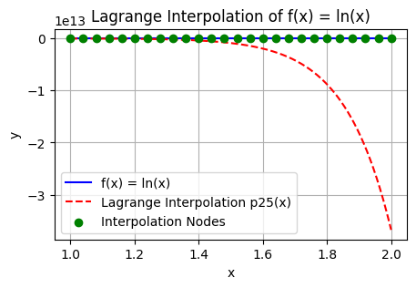

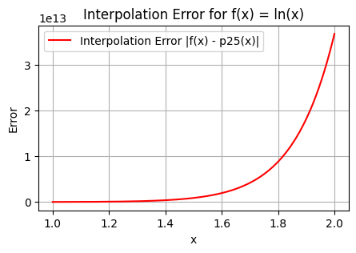

```
Theoretical upper bound of the interpolation error for p25: 4.330384257087018e-39
```

```python
import numpy as np
import matplotlib.pyplot as plt
from scipy.interpolate import lagrange
import math

# Define the function
def f(x):
    return np.log(x)

# Define the interval and the degree of the polynomial
a, b = 1, 2
n = 25

# Generate 26 equally spaced nodes in the interval [1, 2]
x_nodes = np.linspace(a, b, n + 1)
y_nodes = f(x_nodes)

# Compute the Lagrange interpolation polynomial
lagrange_poly = lagrange(x_nodes, y_nodes)

# Generate 400 equally spaced points in the interval [1, 2] for evaluation
x_eval = np.linspace(a, b, 400)
f_eval = f(x_eval)
p25_eval = lagrange_poly(x_eval)

# Compute the maximum absolute error
max_error = np.max(np.abs(f_eval - p25_eval))

print("Maximum Absolute Error:", max_error)

# Plot the original function and the interpolation polynomial
plt.figure(figsize=(5, 3))
plt.plot(x_eval, f_eval, label='f(x) = ln(x)', color='blue')
plt.plot(x_eval, p25_eval, label='Lagrange Interpolation p25(x)', linestyle='--', color='red')
plt.scatter(x_nodes, y_nodes, color='green', zorder=5, label='Interpolation Nodes')
plt.legend()
plt.xlabel('x')
plt.ylabel('y')
plt.title('Lagrange Interpolation of f(x) = ln(x)')
plt.grid(True)
plt.show()

# Plot the interpolation error
interpolation_error = np.abs(f_eval - p25_eval)
plt.figure(figsize=(5, 3))
plt.plot(x_eval, interpolation_error, label='Interpolation Error |f(x) - p25(x)|', color='red')
plt.legend()
plt.xlabel('x')
plt.ylabel('Error')
plt.title('Interpolation Error for f(x) = ln(x)')
plt.grid(True)
plt.show()

# Calculate the theoretical upper bound of the interpolation error using the second interpolation error theorem
# Define the (n+1)-th derivative of the function
def f_derivative_26(x):
    return math.factorial(25) / x**26

# The maximum value of |f^(26)(x)| in the interval [1, 2]
M = np.max(np.abs(f_derivative_26(np.linspace(a, b, 1000))))

# Calculate h
h = (b - a) / n

# Calculate the interpolation error using the second interpolation error theorem
error_bound = (1 / (4 * math.factorial(n + 1))) * M * h**(n + 1)

print("Theoretical upper bound of the interpolation error for p25:", error_bound)
```

$3$

Example Output code that will print the result of the integral using Simpson's rule. If $ n $ is not even, it will print an error message and return $NaN$.

- $(i)$

```python
import numpy as np
import matplotlib.pyplot as plt

def MySimpson(f, a, b, n):
    # Check if n is even
    if n % 2 != 0:
        print("Error: Number of subintervals (n) must be even.")
        return np.nan
    else:
        print(f"Number of subintervals (n) is even: {n}")

    # Calculate the width of each subinterval
    h = (b - a) / n

    # Calculate the integral using Simpson's rule
    integral = f(a) + f(b)

    # Sum the terms with coefficient 4
    for i in range(1, n, 2):
        integral += 4 * f(a + i * h)

    # Sum the terms with coefficient 2
    for i in range(2, n, 2):
        integral += 2 * f(a + i * h)

    # Multiply by h/3
    integral *= h / 3

    return integral

# Define the integrand
def integrand(x):
    return np.sin(x)

# Define the exact value of the integral for comparison
exact_value = 2.0  # Integral of sin(x) from 0 to pi is 2

# Define the interval
a = 0
b = np.pi

# Example usage
n = 10  # Number of subintervals (must be even)
result = MySimpson(integrand, a, b, n)
print("Integral result using Simpson's rule:", result)
```

```
Number of subintervals (n) is even: 10
Integral result using Simpson's rule: 2.0001095173150043
```

- $(ii)$

To investigate if the error reduces as fast as expected when using the composite Simpson's rule to approximate $ \int_0^\pi \sin(x) \, dx $, we need to compare the actual error with the theoretical error bound. The theoretical error bound for the composite Simpson's rule is given by:

$ E(f) \leq \frac{\pi^5}{180 n^4} $

As the analysis continues We will calculate the integral for increasing values of $ n $, compute the actual error, and compare it with the theoretical error bound.

The actual error decreases as $ n $ increases, which is expected. The theoretical error bound also decreases as $ n $ increases.

- In comparison, The actual error is consistently below the theoretical error bound, which confirms that the theoretical bound is valid.
- For the rate of Convergence, The error decreases at a rate proportional to $ \frac{1}{n^4} $, as expected from the theoretical error bound.

In Conclusion, The error reduces as fast as expected when using the composite Simpson's rule to approximate $ \int_0^\pi \sin(x) \, dx $. The actual error is consistently below the theoretical error bound, and the rate of convergence matches the theoretical prediction.

**'This example output from the code in the last question of 3 $(iv)$ confirms the stetement!**

[output not shown]

- $(iii)$

Deriving the $ n $-dependent upper bound of the absolute error for the composite Simpson's rule, we use the error term for Simpson's rule. The error term for the composite Simpson's rule is given by:

$$ E(f) = -\frac{(b - a)h^4}{180} f^{(4)}(\xi) $$

where $ h = \frac{b - a}{n} $ and $ \xi $ is some point in the interval $[a, b]$.

For the integral $ \int_0^\pi \sin(x) \, dx $, the fourth derivative of $ \sin(x) $ is $ \sin(x) $, and its maximum absolute value on the interval $[0, \pi]$ is 1. Therefore, the error term simplifies to:

$$ E(f) \leq \frac{\pi h^4}{180} $$

Since $ h = \frac{\pi}{n} $:

$$ E(f) \leq \frac{\pi \left(\frac{\pi}{n}\right)^4}{180} $$ $$ E(f) \leq \frac{\pi^5}{180 n^4} $$ This gives us the $ n $-dependent upper bound of the absolute error for the composite Simpson's rule.

- $(iv)$

```
Number of subintervals (n) is even: 2
Number of subintervals (n) is even: 4
Number of subintervals (n) is even: 8
Number of subintervals (n) is even: 16
Number of subintervals (n) is even: 32
Number of subintervals (n) is even: 64
Number of subintervals (n) is even: 128
Number of subintervals (n) is even: 256
Number of subintervals (n) is even: 512
Number of subintervals (n) is even: 1024
n         Approximation       Error               Theoretical Error Bound
2         2.0943951023931953  0.09439510239319526 0.10625683499488937
4         2.0045597549844207  0.00455975498442073860.006641052187180586
8         2.000269169948388   0.00026916994838810380.0004150657616987866
16        2.0000165910479355  1.6591047935499148e-052.5941610106174163e-05
32        2.0000010333694127  1.0333694127062643e-061.6213506316358852e-06
64        2.0000000645300013  6.453000134243325e-081.0133441447724283e-07
128       2.000000004032257   4.032257194808153e-096.333400904827677e-09
256       2.000000000252003   2.5200286302151653e-103.958375565517298e-10
512       2.000000000015753   1.575317654101127e-112.4739847284483112e-11
1024      2.000000000000981   9.809930645587883e-131.5462404552801945e-12
```

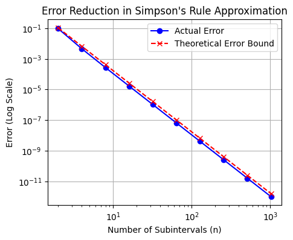

```
n_0 such that the absolute error is less than 10^-4: 12
```

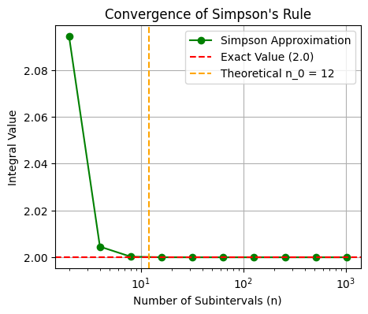

```python
import numpy as np
import matplotlib.pyplot as plt

# Function to perform Simpson's Rule
def MySimpson(f, a, b, n):
    # Check if n is even, as Simpson's Rule requires it
    if n % 2 != 0:
        print("Error: Number of subintervals (n) must be even.")
        return np.nan
    else:
        print(f"Number of subintervals (n) is even: {n}")

    h = (b - a) / n  # Width of each subinterval
    integral = f(a) + f(b)  # Start with the endpoints

    # Sum the terms with coefficient 4 (for odd indexed points)
    for i in range(1, n, 2):
        integral += 4 * f(a + i * h)

    # Sum the terms with coefficient 2 (for even indexed points)
    for i in range(2, n, 2):
        integral += 2 * f(a + i * h)

    # Multiply by h/3
    integral *= h / 3

    return integral

# Define the integrand function
def integrand(x):
    return np.sin(x)

# Exact value of the integral for comparison
exact_value = 2.0  # Integral of sin(x) from 0 to pi is exactly 2

# Define the interval
a = 0
b = np.pi

# List of subintervals to test
subintervals = [2, 4, 8, 16, 32, 64, 128, 256, 512, 1024]

# Store the results in a list
results = []

# Calculate Simpson's Rule for each number of subintervals and compute the error
for n in subintervals:
    approx_value = MySimpson(integrand, a, b, n)
    error = np.abs(exact_value - approx_value)
    theoretical_error_bound = (np.pi**5) / (180 * n**4)  # Simpson's rule theoretical error
    results.append((n, approx_value, error, theoretical_error_bound))

# Print the results
print(f"{'n':<10}{'Approximation':<20}{'Error':<20}{'Theoretical Error Bound':<30}")
for n, approx_value, error, theoretical_error_bound in results:
    print(f"{n:<10}{approx_value:<20}{error:<20}{theoretical_error_bound:<30}")

# Function to plot errors
def plot_errors(results):
    n_values = [result[0] for result in results]
    errors = [result[2] for result in results]
    theoretical_errors = [result[3] for result in results]

    plt.figure(figsize=(5, 4))

    # Plot the actual error
    plt.plot(n_values, errors, marker='o', linestyle='-', color='b', label='Actual Error')

    # Plot the theoretical error bound
    plt.plot(n_values, theoretical_errors, marker='x', linestyle='--', color='r', label='Theoretical Error Bound')

    plt.xscale('log')
    plt.yscale('log')
    plt.xlabel('Number of Subintervals (n)')
    plt.ylabel('Error (Log Scale)')
    plt.title('Error Reduction in Simpson\'s Rule Approximation')
    plt.legend()
    plt.grid(True)
    plt.show()

# Plot the errors
plot_errors(results)

# Calculate n0 such that the absolute error is less than 10^-4
def find_n0(tolerance):
    n0 = (np.pi**5 / (180 * tolerance))**(1/4)
    return int(np.ceil(n0))  # Round up to the nearest integer

# Determine n_0 for which the error is less than 10^-4
tolerance = 1e-4
n0 = find_n0(tolerance)
print("n_0 such that the absolute error is less than 10^-4:", n0)

# Additional plot to show Simpson's Rule convergence behavior
def plot_integral_convergence(results, exact_value):
    n_values = [result[0] for result in results]
    approx_values = [result[1] for result in results]

    plt.figure(figsize=(5, 4))
    plt.plot(n_values, approx_values, marker='o', linestyle='-', color='g', label='Simpson Approximation')
    plt.axhline(y=exact_value, color='r', linestyle='--', label='Exact Value (2.0)')
     #Add vertical line at n = 12
    plt.axvline(x=12, color='orange', linestyle='--', label='Theoretical n_0 = 12')


    plt.xscale('log')
    plt.xlabel('Number of Subintervals (n)')
    plt.ylabel('Integral Value')
    plt.title('Convergence of Simpson\'s Rule')
    plt.legend()
    plt.grid(True)
    plt.show()

# Plot convergence of integral approximation
plot_integral_convergence(results, exact_value)
```

**The output shows that $ n_0 $ such that the absolute error is less than $ 10^{-4} $ is 12. The plot shows the error decreasing as the number of subintervals increases, demonstrating the expected convergence behavior of Simpson's rule.**

```python
import numpy as np

# Calculate n0
tolerance = 1e-4
n0 = (np.pi**5 / (180 * tolerance))**(1/4)
n0 = np.ceil(n0)  # Round up to the nearest integer

print("Theoretical n_0 such that the absolute error is less than 10^-4:", int(n0))
```

```
Theoretical n_0 such that the absolute error is less than 10^-4: 12
```